# Grup G · Pràctica 1. Relacions estructura-funció en proteïnes

Joan Suárez, Mariona Miquel, Martina Xian Porcel, Joan Oliva, Joan Grau

2026-04

# **Pràctica 1. Relacions estructura-funció de proteïnes: IGPS**

### Grup G: Joan Suárez, Mariona Miquel, Martina Xian Porcel, Joan Oliva, Joan Grau

## Índex

1. Sobre la proteïna
   - Estructura
   - Funció
2. Treball amb ChimeraX
   - Estructura secundària
   - Estructura supersecundària i interaccions
   - Estructura terciària
3. Funció de la proteïna
   - Centre actiu i residus rellevants
   - Funció proteïna
   - Modificacions post-translacionals
   - Relació seqüència-estructura-funció
4. Bibliografia

## Sobre la proteïna

Nom del gen: trpC Nom de la proteïna: indole-3-glycerol phosphate synthase (IGPS) Codi UniProt: P9WFX7 Codi BRENDA / EC: EC 4.1.1.48

### Estructura

codi pdb: 3QJA | pdb_00003qja L’estructura 3QJA és la millor opció perquè ofereix la màxima resolució (1,29 Å) per a la proteïna nativa (wild-type), superant en detall atòmic qualsevol altra versió no modificada. A diferència dels codis amb resolució superior (com 5AOU), la 3QJA manté la seqüència original sense mutacions artificials de disseny. A més, en ser una forma apo, proporciona un model estructural pur i sense distorsions causades per lligands. Generalment funciona com a monòmer o dímer segons l’organisme.

### Funció

Catalitza la conversió de 1-(O-carboxifenilamino)-1-desoxiribulosa-5-fosfat en indole-3-glicerol fosfat, un precursor directe del triptòfan. Aquest pas és essencial perquè permet la formació de l’anell indòlic, característic del triptòfan.

## Treball amb ChimeraX

### Estructura secundària

[figure not shown]

L’estructura que es veu combina hèlixs α, làmines β i llaços, i totes aquestes parts s’organitzen mitjançant enllaços que estabilitzen el plegament. Les làmines β es mantenen unides per enllaços d’hidrogen entre cadenes, formant motius com les forquilles β–β o patrons més amplis com la clau grega. Les hèlixs α es mantenen estables gràcies als seus enllaços d’hidrogen interns, i sovint s’empaqueten entre elles mitjançant interaccions hidrofòbiques. Els llaços i girs connecten aquestes estructures i defineixen la geometria global. En conjunt, aquests enllaços d’hidrogen, hidrofòbics, electrostàtics i, si n’hi ha, disulfur donen forma a les estructures supersecundàries i permeten que la proteïna adopti un plegament estable i funció.

### Estructura supersecundària i interaccions

blau= ponts d’hidrogen vermell= forces de Van der Waals

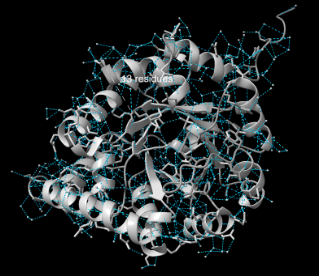

Figura 2. Estructura de la proteïna mostrant el segment de 13 residus i els seus ponts d’hidrogen (en blau) amb la resta de la cadena.

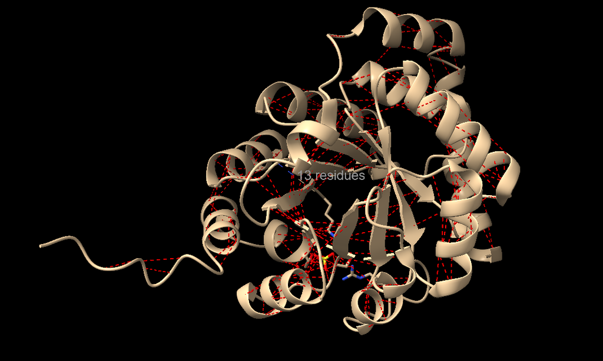

Figura 3. Estructura de la proteïna amb el mateix segment de 13 residus, destacant les forces de Van der Waals (en vermell) que estableix amb l’entorn.

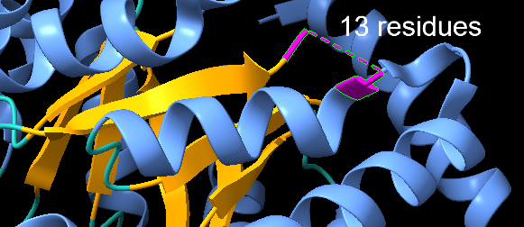

### Estructura terciària

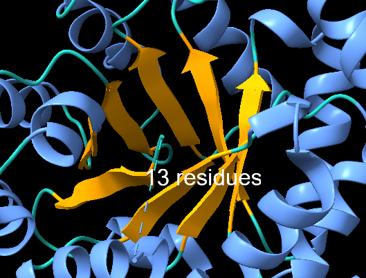

Figura 5: Barril α/β (TIM barrel)

Barril α/β (TIM barrel) Està format per: - 8 làmines β internes (formen el barril) - 8 hèlixs α externes El centre actiu es troba a la part superior del barril

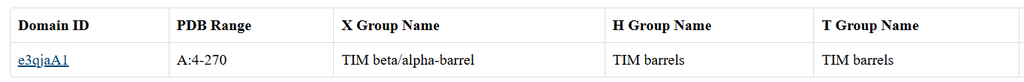

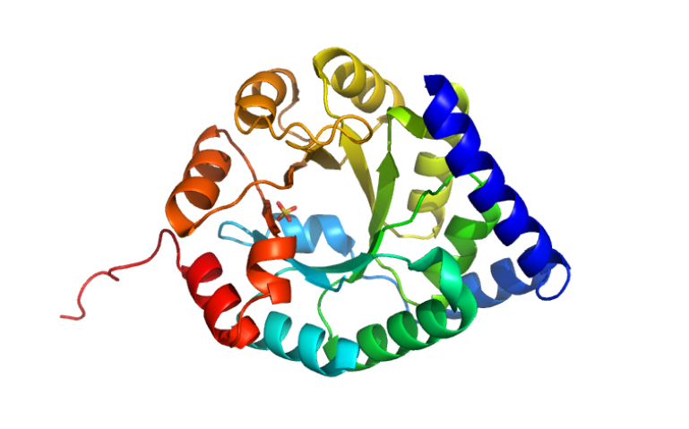

Figura 6 i 7. Domini segons ECOD. Domini e3qjaA1 (A:4–270) classificat com a TIM β/α‑barrel dins dels grups TIM barrels.

## Funció de la proteïna

### Centre actiu i Residus rellevants

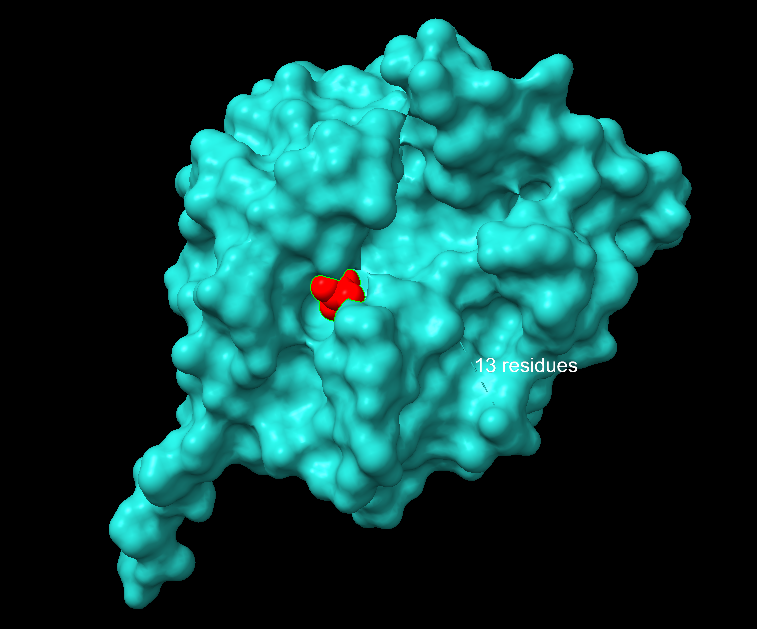

Figura 8: Centre actiu de la proteïna

Identificació del centre actiu: El centre actiu d’aquesta proteïna es troba a la part superior del barril α/β (també conegut com a barril TIM). Segons la literatura, els residus més rellevants del centre actiu són Glu57, Lys59, Lys119, Glu168 i Glu219, ja que la seva mutació provoca una pèrdua molt important o total de l’activitat enzimàtica. En particular, Lys119 s’ha proposat com el residu que actua com a àcid catalític en el pas de ciclació, mentre que Glu168 podria estabilitzar un intermedi carregat positivament i actuar també com a base catalítica. A més, s’ha suggerit que Glu57, Lys119 i Glu219 formen una xarxa funcional que modula la reactivitat de Lys119 i, per tant, l’activitat global de l’enzim (Konas et al., 2023). L’estructura 3QJA és una estructura en forma apo, és a dir, no inclou ni el substrat natural ni cap inhibidor unit al centre actiu. Segons l’entrada del PDB, l’únic heterolligand present és un ió sulfat (SO4), que molt probablement deriva de les condicions de cristal·lització i no correspon a un lligand fisiològic implicat directament en la catàlisi. Per tant, aquesta estructura permet identificar molt bé la cavitat del centre actiu i la disposició dels residus catalítics, però no permet observar directament un complex enzim-substrat o enzim-inhibidor (RCSB PDB, 2011). Tot i això, la literatura basada en altres estructures de la mateixa proteïna, especialment el complex 3T44 amb el producte IGP, permet descriure les interaccions més probables del centre actiu. En aquest complex, els àtoms de nitrogen del backbone de Gly221, Gly242 i Glu243 formen ponts d’hidrogen amb els oxígens del grup fosfat de l’IGP. La cadena lateral de Lys59 estableix ponts d’hidrogen tant amb un oxigen del fosfat com amb un grup hidroxil del lligand. Lys119 està situada de manera compatible amb una interacció catió-π amb la part indòlica del producte, mentre que Glu168 pot formar un pont d’hidrogen amb el grup N-H de l’IGP i contribuir a estabilitzar l’intermedi de reacció. També s’ha descrit una xarxa de ponts d’hidrogen entre Glu168, Asn189 i Ser220, que podria participar en la unió del lligand i/o en la catàlisi (Esposito et al., 2022).

### Funció proteïna

Es tracta d’un enzim de la via de biosíntesi del triptòfan que catalitza la conversió de CdRP (1-(2-carboxyphenylamino)-1-deoxy-D-ribulose 5-phosphate) en IGP (indole-3-glycerol phosphate), un precursor directe del triptòfan. Per això, la seva funció és essencial en la formació de l’anell indòlic característic d’aquest aminoàcid. El mecanisme de reacció consta, de manera general, de tres etapes principals: ciclació, descarboxilació i deshidratació. Primer, el substrat s’uneix al centre actiu i es reorganitza per permetre el tancament de l’anell; després es produeix la pèrdua de CO₂; i finalment s’elimina H₂O, obtenint-se el producte IGP. Així, l’enzim transforma un compost lineal en una molècula cíclica aromàtica pròpia de la biosíntesi del triptòfan.

### Modificacions post-translacionals

En el cas de la proteïna indole-3-glycerol phosphate synthase (TrpC), segons la informació disponible a la base de dades UniProt, no s’han descrit modificacions post-traduccionals rellevants ni reguladores associades a aquesta proteïna. Tampoc hi ha evidència experimental consistent de fosforilació, acetilació, metilació o altres modificacions que tinguin un paper funcional en l’activitat de l’enzim. Això és coherent amb el fet que es tracta d’un enzim metabòlic bacterià altament conservat, on la regulació acostuma a produir-se principalment a nivell d’expressió gènica dins de la via de biosíntesi del triptòfan, més que no pas per modificacions post-traduccionals.

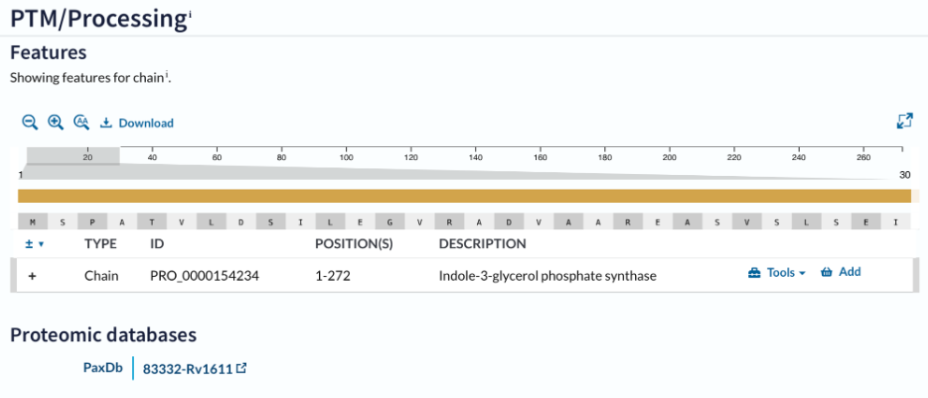

Figura 9: Post-traductional modifications segons UNIPROT

### Relació seqüència-estructura-funció

L’IGPS (indole-3-glycerol phosphate synthase, gen trpC) és un exemple per veure com la seqüència d’aminoàcids acaba determinant l’estructura i, al final, la funció de l’enzim dins la via del triptòfan. A nivell d’estructura, el que s’observa és el típic plegament de barril TIM (α/β)₈. Això, dit de forma simple, vol dir que la proteïna s’organitza com un “cilindre” format per làmines β al centre i hèlixs α al voltant. Aquesta arquitectura no és casual: crea una butxaca interna molt estable on es forma el centre actiu. Justament aquí és on l’enzim pot fer la seva funció sense que l’aigua o l’entorn interfereixin massa, cosa important perquè la reacció té intermedis inestables. La funció de l’IGPS és catalitzar un pas concret de la síntesi del triptòfan (la conversió del CDRP a IGP), i per això necessita una col·locació molt precisa del substrat. Això s’aconsegueix gràcies a diferents tipus de residus al centre actiu: Hi ha residus bàsics (sobretot lisines i arginines) que serveixen per “agafar” el substrat, sobretot el grup fosfat, i mantenir-lo ben fixat. També hi ha un residu àcid important (com un glutamat) que participa directament en la reacció, ajudant en passos de transferència de protons. I altres residus com asparagines que no catalitzen directament, però ajuden a estabilitzar intermedis de la reacció amb ponts d’hidrogen. Un altre punt clau són els bucles (loops) que tapen el centre actiu. No són estructures rígides: es mouen. Quan entra el substrat, el bucle es tanca una mica i això ajuda a “segellar” la reacció. Això evita que els intermedis s’escapin i fa que l’enzim sigui molt més eficient. Pel que fa a la relació seqüència-funció, el més important és que aquests residus estan molt conservats. Això vol dir que si els canvies, la funció es veu afectada gairebé sempre. En el cas de variants: Si es muten les lisines o arginines del centre actiu, el substrat ja no s’uneix igual i l’enzim perd molta eficiència (li costa més treballar perquè no “enganxa” bé el substrat). Si es canvia el glutamat catalític, directament la reacció pot deixar de funcionar, perquè es perd una part clau del mecanisme químic. Si els loops no funcionen bé o perden flexibilitat, el centre actiu queda massa obert i els intermedis no es protegeixen bé, i això també fa baixar molt l’activitat. Per últim, la seqüència que ens heu passat acaba amb una His-tag (cua d’histidines), que en realitat no forma part de la proteïna natural. S’hi posa en laboratoris per poder purificar-la més fàcilment, però no té funció enzimàtica. Així doncs, podem concluir que el que es veu clar és que l’IGPS funciona perquè té una estructura molt ben “dissenyada”: un barril TIM que crea el lloc actiu, residus concrets que fan la química i uns loops que controlen l’entrada i sortida del substrat. Sense aquesta combinació, l’enzim no podria fer la seva funció correctament.

## Bibliografia

- Esposito, N., Konas, D. W., & Goodey, N. M. (2022). Indole-3-glycerol phosphate synthase from Mycobacterium tuberculosis: A potential new drug target. ChemBioChem, 23(2), e202100314. doi:10.1002/cbic.202100314 n
- Konas, D. W., Cho, S., Thomas, O. D., Bhatti, M. M., Leon Hernandez, K., Moran, C., Booter, H., Candela, T., Lacap, J., McFadden, P., van den Berg, S., Welter, A. M., Peralta, A., Janson, C. A., Catalano, J., & Goodey, N. M. (2023). Investigating the roles of active site residues in Mycobacterium tuberculosis indole-3-glycerol phosphate synthase, a potential target for antitubercular agents. ACS Bio & Med Chem Au, 3(5), 438–447. doi:10.1021/acsbiomedchemau.3c00029
- RCSB Protein Data Bank. (2011). 3QJA: Crystal structure of the Mycobacterium tuberculosis indole-3-glycerol phosphate synthase (TrpC) in apo form. doi:10.2210/pdb3QJA/pdb
- UniProt Consortium. (2017). P9WFX7 (TRPC_MYCTU): Indole-3-glycerol phosphate synthase. UniProtKB/Swiss-Prot.